# PCA with Adegenet

J. Ignacio Lucas Lledó

27/5/2022

## Introduction

In folder `2022-05-09`, Mar performed a PCA analysis using functions from the SNPRelate R package. Here I want to reproduce the PCA analysis with Adegenet, in order to solve issues with the import of data with Adegenet.

```r
suppressMessages(library('ape'))
suppressMessages(library('pegas'))
suppressMessages(library('seqinr'))
suppressMessages(library('ggplot2'))
suppressMessages(library('adegenet'))
library('MetBrewer')
library(kableExtra)

# Mar, observa l'ús d'adreces relatives, que també funcionaran en la teua carpeta:
VCF <- '../2022-05-04/strict.recode.vcf'
```

We can use `read.vcf()`, from package `pegas`, to read a VCF into a kind of data frame, [see this tutorial by Emmanuel Paradis](https://archive.linux.duke.edu/cran/web/packages/pegas/vignettes/ReadingFiles.pdf) which can then be turned into a `genind` object, which is acceptable for the whole set of individuals, with exactly 24878 loci after the last filtering.

```r
snps <- read.vcf(VCF, from = 1, to = 24878, quiet = TRUE)
snps <- as.data.frame(snps)
for (i in 1:24878) snps[,i] <- as.character(snps[,i])
snps[snps == './.'] <- NA

# The argument "NA.char" in df2genind does not work.
snps.gi <- df2genind(snps, sep = '/', type = 'codom', ploidy = 2)
sum(is.na(snps.gi@tab))
```

```
## [1] 92682
```

To run the PCA, I follow the [basic tutorial of the adegenet package](https://github.com/thibautjombart/adegenet/raw/master/tutorials/tutorial-basics.pdf):

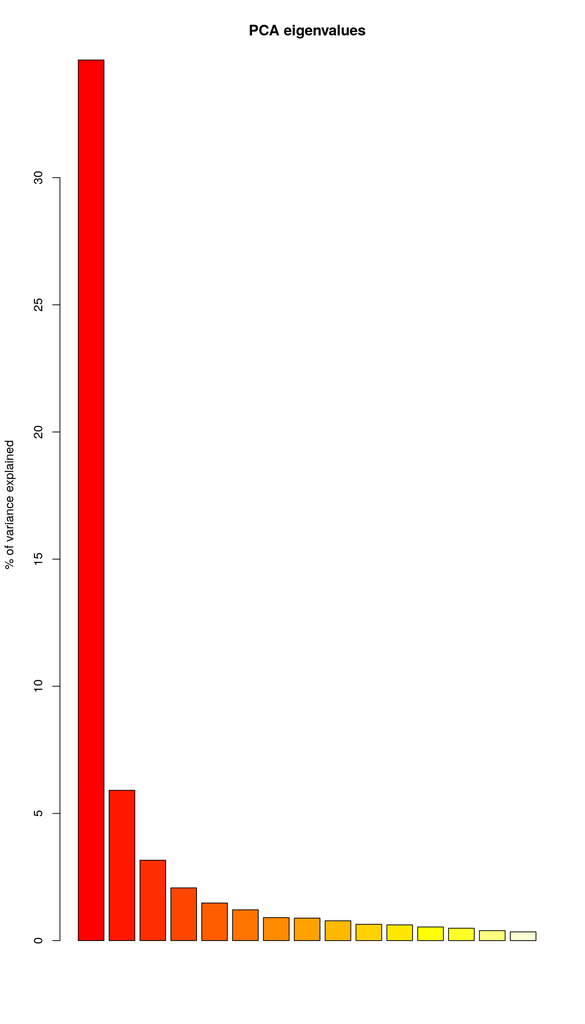

```r
# This changes the genotype data to allele frequency per individual, substituting
# missing data by average allele frequency. With 2 alleles per locus, this duplicates
# the number of columns in the table.
X <- tab(snps.gi, NA.method = 'mean')
pca1 <- dudi.pca(X, scale=FALSE, scannf=FALSE, nf=3)
barplot(100 * pca1$eig[1:15] / sum(pca1$eig), main = 'PCA eigenvalues',
        col = heat.colors(15), ylab = "% of variance explained")
```

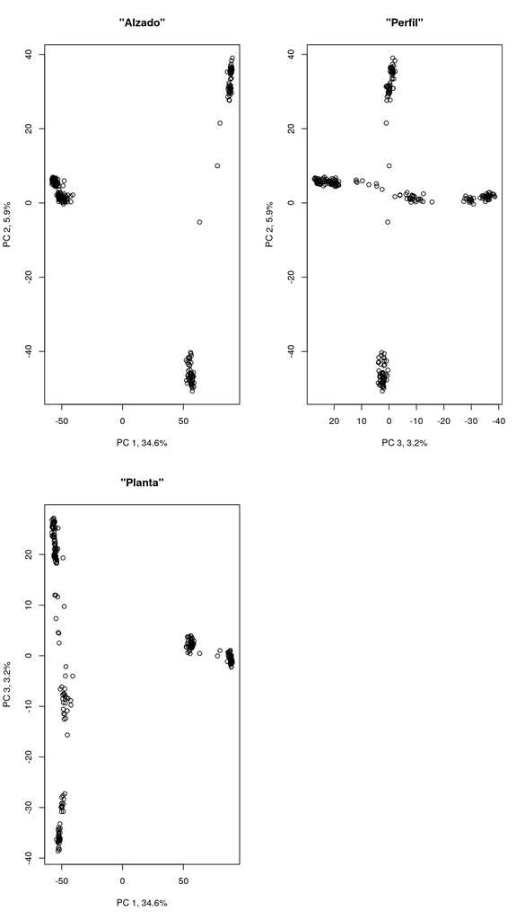

```r
PercentVar <- head(100 * pca1$eig / sum(pca1$eig))
par(mfrow = c(2,2))
plot(pca1$li$Axis1, pca1$li$Axis2,
     xlab = sprintf("PC 1, %.1f%%", PercentVar[1]),
     ylab = sprintf("PC 2, %.1f%%", PercentVar[2]), main = '"Alzado"')
plot(pca1$li$Axis3, pca1$li$Axis2,
     xlim = c(max(pca1$li$Axis3), min(pca1$li$Axis3)),
     xlab = sprintf("PC 3, %.1f%%", PercentVar[3]),
     ylab = sprintf("PC 2, %.1f%%", PercentVar[2]), main = '"Perfil"')
plot(pca1$li$Axis1, pca1$li$Axis3,
     xlab = sprintf("PC 1, %.1f%%", PercentVar[1]),
     ylab = sprintf("PC 3, %.1f%%", PercentVar[3]), main = '"Planta"')
par(mfrow = c(1,1))
```

So, the PCA seem to reproduce Mar’s results.

Time to assign attributes to the individuals: lake, potential species, PC clúster…

```r
DATA <- '../../data/Fish_clean2.tsv'
Fish <- read.delim(DATA)
row.names(Fish) <- Fish$Fish_code
kable(table(Fish$MOL_MORPH_CONSENSUS_ID,
            Fish$Sci_name_CONSENSUS_ID),
      useNA = 'always') %>% kable_styling()
```

|  | C.acrinasus | C.albellus | C.alpinus | C.alpinus/C.steinmanni | C.brienzii | C.brienzii/C.fatioi | C.confusus | C.duplex | C.fatioi | C.fatioi/C.albellus | C.heglingus | C.palaea | C.profundus | C.steinmanni | C.zuerichensis | D | L | not dissected | notdissected | P |
| --- | --- | --- | --- | --- | --- | --- | --- | --- | --- | --- | --- | --- | --- | --- | --- | --- | --- | --- | --- | --- |
| Albock | 39 | 0 | 0 | 0 | 0 | 0 | 0 | 0 | 0 | 0 | 0 | 0 | 0 | 0 | 0 | 0 | 0 | 0 | 0 | 0 |
| Balchen1 | 0 | 0 | 12 | 0 | 0 | 0 | 0 | 0 | 0 | 0 | 0 | 0 | 0 | 0 | 0 | 0 | 0 | 0 | 0 | 0 |
| Balchen1/Balchen2 | 0 | 0 | 0 | 1 | 0 | 0 | 0 | 0 | 0 | 0 | 0 | 0 | 0 | 0 | 0 | 0 | 0 | 0 | 0 | 0 |
| Balchen2 | 0 | 0 | 0 | 0 | 17 | 0 | 0 | 0 | 0 | 0 | 0 | 0 | 0 | 22 | 0 | 0 | 0 | 0 | 0 | 0 |
| Balchen2/Felchen | 0 | 0 | 0 | 0 | 0 | 6 | 0 | 0 | 0 | 0 | 0 | 0 | 0 | 0 | 0 | 0 | 0 | 0 | 0 | 0 |
| Bondelle | 0 | 0 | 0 | 0 | 0 | 0 | 93 | 0 | 0 | 0 | 0 | 0 | 0 | 0 | 0 | 0 | 0 | 0 | 0 | 0 |
| Brienzlig | 0 | 62 | 0 | 0 | 0 | 0 | 0 | 0 | 0 | 0 | 0 | 0 | 0 | 0 | 0 | 0 | 0 | 0 | 0 | 0 |
| C.duplex | 0 | 0 | 0 | 0 | 0 | 0 | 0 | 59 | 0 | 0 | 0 | 0 | 0 | 0 | 0 | 0 | 0 | 0 | 0 | 0 |
| C.heglingus | 0 | 0 | 0 | 0 | 0 | 0 | 0 | 0 | 0 | 0 | 42 | 0 | 0 | 0 | 0 | 0 | 0 | 0 | 0 | 0 |
| C.zuerichensis | 0 | 0 | 0 | 0 | 0 | 0 | 0 | 0 | 0 | 0 | 0 | 0 | 0 | 0 | 28 | 0 | 0 | 0 | 0 | 0 |
| D | 0 | 0 | 0 | 0 | 0 | 0 | 0 | 0 | 0 | 0 | 0 | 0 | 0 | 0 | 0 | 6 | 0 | 0 | 0 | 0 |
| Felchen | 0 | 0 | 0 | 0 | 0 | 0 | 0 | 0 | 47 | 0 | 0 | 0 | 0 | 0 | 0 | 0 | 0 | 0 | 0 | 0 |
| Felchen/Brienzlig | 0 | 0 | 0 | 0 | 0 | 0 | 0 | 0 | 0 | 3 | 0 | 0 | 0 | 0 | 0 | 0 | 0 | 0 | 0 | 0 |
| kropfer | 0 | 0 | 0 | 0 | 0 | 0 | 0 | 0 | 0 | 0 | 0 | 0 | 3 | 0 | 0 | 0 | 0 | 0 | 0 | 0 |
| Kropfer | 0 | 0 | 0 | 0 | 0 | 0 | 0 | 0 | 0 | 0 | 0 | 0 | 48 | 0 | 0 | 0 | 0 | 0 | 0 | 0 |
| L | 0 | 0 | 0 | 0 | 0 | 0 | 0 | 0 | 0 | 0 | 0 | 0 | 0 | 0 | 0 | 0 | 113 | 0 | 0 | 0 |
| not dissected | 0 | 0 | 0 | 0 | 0 | 0 | 0 | 0 | 0 | 0 | 0 | 0 | 0 | 0 | 0 | 0 | 0 | 48 | 0 | 0 |
| notdissected | 0 | 0 | 0 | 0 | 0 | 0 | 0 | 0 | 0 | 0 | 0 | 0 | 0 | 0 | 0 | 0 | 0 | 0 | 32 | 0 |
| P | 0 | 0 | 0 | 0 | 0 | 0 | 0 | 0 | 0 | 0 | 0 | 0 | 0 | 0 | 0 | 0 | 0 | 0 | 0 | 61 |
| Palée | 0 | 0 | 0 | 0 | 0 | 0 | 0 | 0 | 0 | 0 | 0 | 1 | 0 | 0 | 0 | 0 | 0 | 0 | 0 | 0 |

Among all fish in the original data (including many not sequenced), the correspondance between molecular-morphological labels and scientific names is high. The only ambiguity happens for the molecular-morphological label “Balchen2”, which is used in 17 fish assigned to *C. brienzii* and in 22 fish assigned to *C. steinmanni*. They could be synonimous. In all, and excluding the unknown or not dissected fish, 17 labels are sufficient if we collapse *C. brienzii* and *C. steinmanni*. Otherwise, 18.

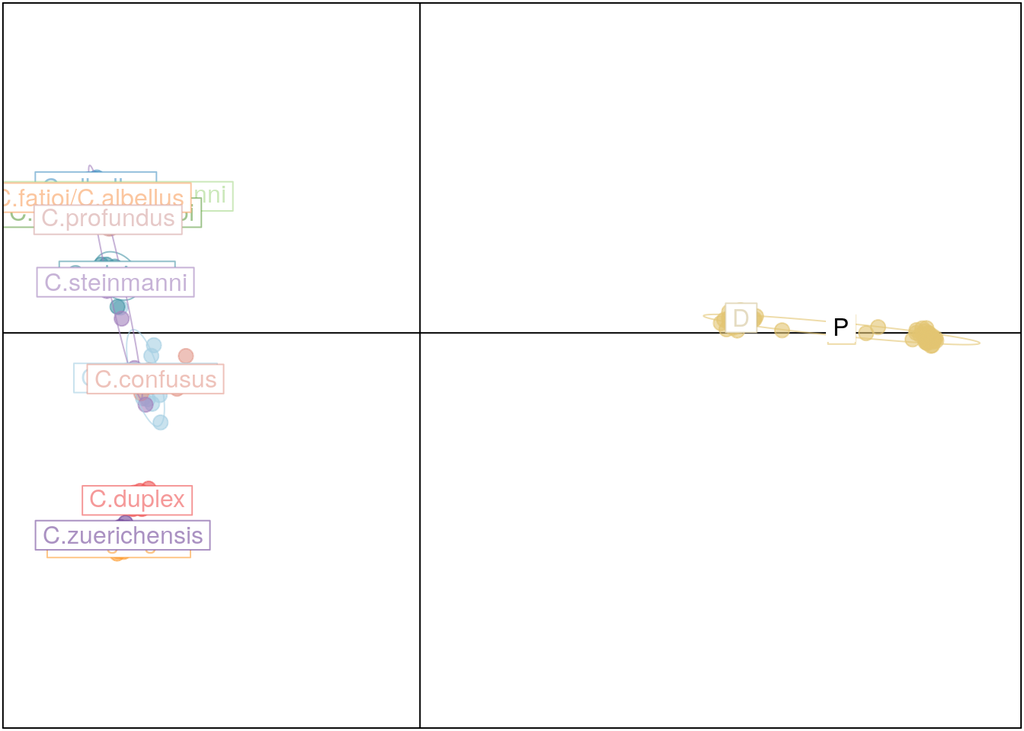

```r
snps.gi@pop <- Fish[row.names(snps.gi@tab), 'Sci_name_CONSENSUS_ID']
col <- funky(18)
s.class(pca1$li, pop(snps.gi), xax = 1, yax = 3, col=transp(col, .6), axesell=FALSE, cstar=0, cpoint=2, grid = FALSE)
```

## Separate analyses for the two regions

```r
Fish.used <- row.names(snps)
Fish.alpine <- intersect(Fish.used, row.names(Fish[Fish$Region == 'Alpine',]))
Fish.arctic <- intersect(Fish.used, row.names(Fish[Fish$Region == 'Arctic',]))
write.table(Fish.alpine, file = 'Alpine.txt', quote = FALSE,
            row.names = FALSE, col.names = FALSE)
write.table(Fish.arctic, file = 'Arctic.txt', quote = FALSE,
            row.names = FALSE, col.names = FALSE)
```

```bash
VCF='../2022-04-22/assem2_outfiles/assem2.vcf'
if [ ! -e alpine.recode.vcf ]; then
   vcftools --vcf $VCF \
            --out dirty \
            --keep Alpine.txt \
            --recode \
            --recode-INFO-all
   vcftools --vcf dirty.recode.vcf \
            --out alpine \
            --thin 500 \
            --remove-indels \
            --mac 2 \
            --max-alleles 2 \
            --max-meanDP 1000 \
            --max-missing-count 7 \
            --recode --recode-INFO-all
fi
if [ -e dirty.recode.vcf ]; then rm dirty.recode.vcf; fi

if [ ! -e arctic.recode.vcf ]; then
   vcftools --vcf $VCF \
            --out dirty \
            --keep Arctic.txt \
            --recode \
            --recode-INFO-all
   vcftools --vcf dirty.recode.vcf \
            --out arctic \
            --thin 500 \
            --remove-indels \
            --mac 2 \
            --max-alleles 2 \
            --max-meanDP 1000 \
            --max-missing-count 6 \
            --recode --recode-INFO-all
fi
if [ -e dirty.recode.vcf ]; then rm dirty.recode.vcf; fi
```

```
##
## VCFtools - 0.1.17
## (C) Adam Auton and Anthony Marcketta 2009
##
## Parameters as interpreted:
##  --vcf ../2022-04-22/assem2_outfiles/assem2.vcf
##  --keep Alpine.txt
##  --recode-INFO-all
##  --out dirty
##  --recode
##
## Keeping individuals in 'keep' list
## After filtering, kept 157 out of 280 Individuals
## Outputting VCF file...
## After filtering, kept 879238 out of a possible 879238 Sites
## Run Time = 176.00 seconds
##
## VCFtools - 0.1.17
## (C) Adam Auton and Anthony Marcketta 2009
##
## Parameters as interpreted:
##  --vcf dirty.recode.vcf
##  --recode-INFO-all
##  --mac 2
##  --max-alleles 2
##  --max-missing-count 7
##  --max-meanDP 1e+03
##  --thin 500
##  --out alpine
##  --recode
##  --remove-indels
##
## After filtering, kept 157 out of 157 Individuals
## Outputting VCF file...
## After filtering, kept 20628 out of a possible 879238 Sites
## Run Time = 41.00 seconds
##
## VCFtools - 0.1.17
## (C) Adam Auton and Anthony Marcketta 2009
##
```

[output cut: 17 more lines]

```
##  --vcf dirty.recode.vcf
##  --recode-INFO-all
##  --mac 2
##  --max-alleles 2
##  --max-missing-count 6
##  --max-meanDP 1e+03
##  --thin 500
##  --out arctic
##  --recode
##  --remove-indels
##
## After filtering, kept 114 out of 114 Individuals
## Outputting VCF file...
## After filtering, kept 27225 out of a possible 879238 Sites
## Run Time = 30.00 seconds
```

## Alpine lakes

```r
alp <- read.vcf('alpine.recode.vcf', from = 1, to = 100000, quiet = TRUE)
alp <- as.data.frame(alp)
for (i in 1:dim(alp)[2]) alp[,i] <- as.character(alp[,i])
alp[alp == './.'] <- NA

alp.gi <- df2genind(alp, sep = '/', type = 'codom', ploidy = 2)
alp.gi@pop <- droplevels(Fish[row.names(alp.gi@tab), 'Sci_name_CONSENSUS_ID'])
#levels(alp.gi@pop) <- c(levels(alp.gi@pop), 'unknown')
alp.gi@pop[is.na(alp.gi@pop)] <- 'unknown'
```

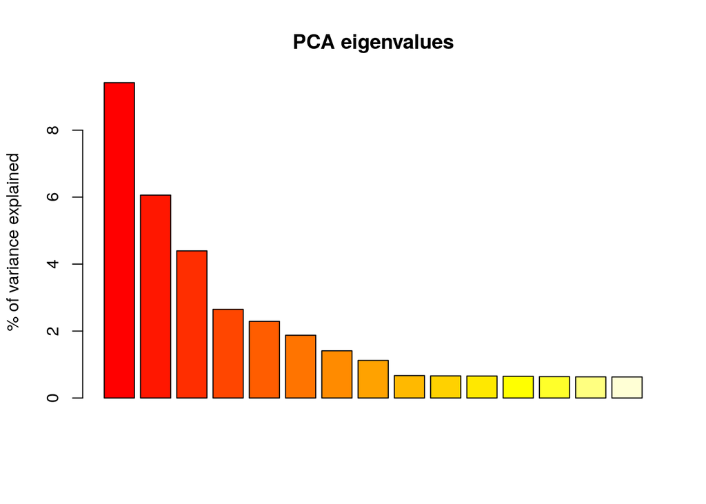

```r
X <- tab(alp.gi, NA.method = 'mean')
pca2 <- dudi.pca(X, scale=FALSE, scannf=FALSE, nf=3)
barplot(100 * pca2$eig[1:15] / sum(pca2$eig), main = 'PCA eigenvalues',
        col = heat.colors(15), ylab = "% of variance explained")
```

```r
PercentVar <- head(100 * pca2$eig / sum(pca2$eig))
```

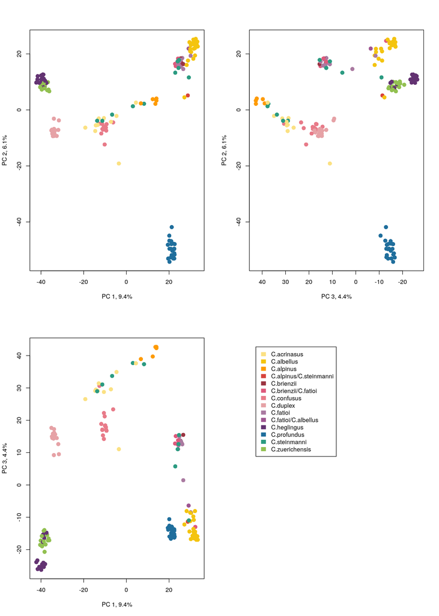

```r
library(MetBrewer)
col  <- met.brewer('Signac', 14)  # Lakota, Juarez, Signac
#colt <- transp(col, 0.6)
par(mfrow = c(2,2))
plot(pca2$li$Axis1, pca2$li$Axis2,
     xlab = sprintf("PC 1, %.1f%%", PercentVar[1]),
     ylab = sprintf("PC 2, %.1f%%", PercentVar[2]),
     col = col[alp.gi@pop], pch = 16, cex = 1.5)
plot(pca2$li$Axis3, pca2$li$Axis2,
     xlim = c(max(pca2$li$Axis3), min(pca2$li$Axis3)),
     xlab = sprintf("PC 3, %.1f%%", PercentVar[3]),
     ylab = sprintf("PC 2, %.1f%%", PercentVar[2]),
     col = col[alp.gi@pop], pch = 16, cex = 1.5)
plot(pca2$li$Axis1, pca2$li$Axis3,
     xlab = sprintf("PC 1, %.1f%%", PercentVar[1]),
     ylab = sprintf("PC 3, %.1f%%", PercentVar[3]),
     col = col[alp.gi@pop], pch = 16, cex = 1.5)
plot(c(-40, 20), c(-20, 40), type = 'n', axes = FALSE, ann = FALSE)
legend(-40, y = 40, legend = levels(alp.gi@pop), fill = col, border= col)
```

```r
par(mfrow = c(1,1))
```

## Arctic lakes

```r
arc <- read.vcf('arctic.recode.vcf', from = 1, to = 100000, quiet = TRUE)
arc <- as.data.frame(arc)
for (i in 1:dim(arc)[2]) arc[,i] <- as.character(arc[,i])
arc[arc == './.'] <- NA

arc.gi <- df2genind(arc, sep = '/', type = 'codom', ploidy = 2)
sum(is.na(arc.gi@tab))
```

```
## [1] 36294
```

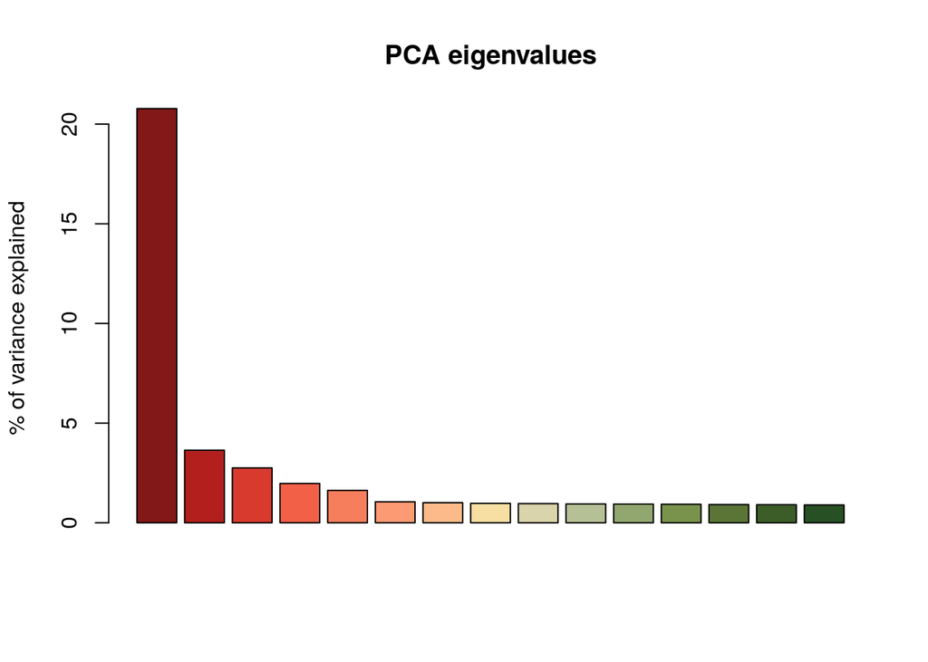

```r
X <- tab(arc.gi, NA.method = 'mean')
pca3 <- dudi.pca(X, scale=FALSE, scannf=FALSE, nf=3)
barplot(100 * pca3$eig[1:15] / sum(pca3$eig), main = 'PCA eigenvalues',
        col = met.brewer('Paquin', 15), ylab = "% of variance explained")
```

```r
PercentVar <- head(100 * pca3$eig / sum(pca3$eig))
```

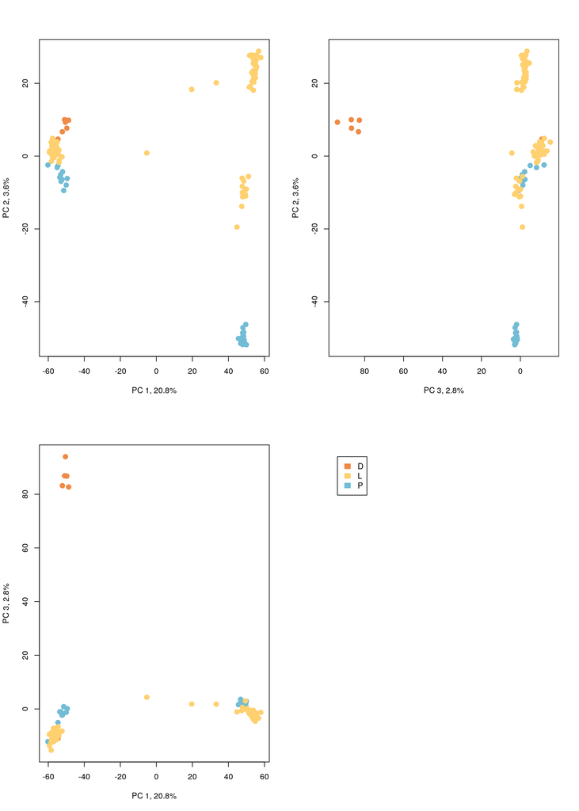

```r
arc.gi@pop <- droplevels(Fish[row.names(arc.gi@tab), 'Sci_name_CONSENSUS_ID'])
col  <- met.brewer('Hiroshige', 3)
#colt <- transp(col, 0.6)
par(mfrow = c(2,2))
plot(pca3$li$Axis1, pca3$li$Axis2,
     xlab = sprintf("PC 1, %.1f%%", PercentVar[1]),
     ylab = sprintf("PC 2, %.1f%%", PercentVar[2]),
     col = col[arc.gi@pop], pch = 16, cex = 1.5)
plot(pca3$li$Axis3, pca3$li$Axis2,
     xlim = c(max(pca3$li$Axis3), min(pca3$li$Axis3)),
     xlab = sprintf("PC 3, %.1f%%", PercentVar[3]),
     ylab = sprintf("PC 2, %.1f%%", PercentVar[2]),
     col = col[arc.gi@pop], pch = 16, cex = 1.5)
plot(pca3$li$Axis1, pca3$li$Axis3,
     xlab = sprintf("PC 1, %.1f%%", PercentVar[1]),
     ylab = sprintf("PC 3, %.1f%%", PercentVar[3]),
     col = col[arc.gi@pop], pch = 16, cex = 1.5)
plot(c(-40, 20), c(-20, 40), type = 'n', axes = FALSE, ann = FALSE)
legend(-40, y = 40, legend = levels(arc.gi@pop), fill = col, border= col)
```

```r
par(mfrow = c(1,1))
```